# Predict race/ethnicity based on census data

## Setups

```r
if (!requireNamespace('wru')) install.packages('wru')

library(wru)
library(tidyverse)
library(lubridate)
source('utils/r-utils.R')

theme_set(
  theme_bw() +
    theme(legend.title = element_blank()))
```

## Load data

and use the `wru` package to predict race based on last_names only

```r
all_full_names <- read_tsv('data/names/full-names.tsv.xz')
articles <- read_tsv('data/pubmed/articles.tsv.xz')
pubmed_race_pmids <-
  read_tsv('data/names/corresponding-authors.tsv.xz') %>%
  left_join(read_tsv('data/pubmed/articles.tsv.xz'), by = 'pmid') %>%
  mutate(year = substr(publication_date, 1, 4) %>% ymd(truncated = 2),
         publication_date = ymd(publication_date, truncated = 2)) %>%
  rename('surname' = last_name_simple) %>%
  predict_race(surname.only = T, impute.missing = F)
```

```
## [1] "Proceeding with surname-only predictions..."
```

```r
pubmed_race_df <- pubmed_race_pmids %>%
  group_by(pmid, journal, publication_date, year) %>%
  summarise_at(vars(pred.whi:pred.oth), mean, na.rm = T) %>%
  ungroup()

iscb_race_df <- read_tsv('data/iscb/keynotes.tsv') %>%
  left_join(all_full_names, by = c('fore_name', 'last_name')) %>%
  rename('surname' = last_name_simple) %>%
  mutate(year = ymd(year, truncated = 2)) %>%
  predict_race(surname.only = T, impute.missing = F) %>%
  filter(conference != 'PSB') # remove PSB
```

```
## [1] "Proceeding with surname-only predictions..."
```

```r
alpha_threshold <- qnorm(0.975)
start_year <- 1992
end_year <- 2019
n_years <- end_year - start_year
my_jours <- unique(pubmed_race_df$journal)
my_confs <- unique(iscb_race_df$conference)
n_jours <- length(my_jours)
n_confs <- length(my_confs)
race_levels <- c('White', 'Asian', 'Black', 'Hispanic', 'Other', 'Other categories')
```

Missing data

```r
# 10 random unmatched names
iscb_race_df %>%
  filter(is.na(pred.whi)) %>%
  select(1,2) %>%
  sample_n(10)
```

```
##          year        full_name.x
## 1  2010-01-01      Phil Kapranov
## 2  2001-01-01  Gunnar von Jeijne
## 3  2010-01-01   Cecilia Arraiano
## 4  2012-01-01       Jill Mesirov
## 5  2000-01-01    Minoru Kanehisa
## 6  2017-01-01   Olga Troyanskaya
## 7  2014-01-01 Isaac (Zak) Kohane
## 8  2002-01-01  Terry Gaasterland
## 9  2015-01-01       Amos Bairoch
## 10 2003-01-01      David Sankoff
```

```r
pubmed_race_pmids %>%
  filter(is.na(last_name)) %>%
  nrow()
```

```
## [1] 39
```

```r
pubmed_race_pmids %>%
  filter(is.na(surname)) %>%
  nrow()
```

```
## [1] 40
```

```r
pubmed_race_pmids %>%
  filter(!is.na(surname)&is.na(pred.whi)) %>%
  nrow()
```

```
## [1] 8770
```

```r
iscb_race_df %>%
  filter(is.na(pred.whi)) %>%
  nrow()
```

```
## [1] 100
```

```r
iscb_race_df %>%
  filter(is.na(pred.whi)) %>%
  select(surname) %>%
  sample_n(10)
```

```
##        surname
## 1       kohane
## 2       ruppin
## 3     apweiler
## 4       koonin
## 5     gingeras
## 6    kerlavage
## 7  troyanskaya
## 8       heijne
## 9      royyuru
## 10     abagyan
```

## Prepare data frames for later analyses

- bind_rows results of race predictions in iscb and Pubmed authors
- pivot long
- compute mean, sd, marginal error
- add “Other categories”
- separate by journals
- separate by conference keynote speakers/fellows

```r
iscb_pubmed <- iscb_race_df %>%
  rename('journal' = conference) %>%
  select(year, journal, contains('pred')) %>%
  mutate(publication_date = year,
         type = 'Keynote speakers/Fellows') %>%
  bind_rows(
    pubmed_race_df %>%
      select(year, journal, contains('pred'), publication_date) %>%
      mutate(type = 'Pubmed authors')
  ) %>%
  mutate(pred_sum_others = pred.his + pred.oth + pred.bla) %>%
  pivot_longer(contains('pred'),
               names_to = 'Race',
               values_to = 'probabilities') %>%
  recode_race() %>%
  group_by(type, year, publication_date, Race) %>%
  add_count() %>%
  mutate(
    mean_prob = mean(probabilities, na.rm = T),
    sd_prob = sd(probabilities, na.rm = T),
    n = mean(n),
    me_prob = alpha_threshold * sd_prob / sqrt(n)
  ) %>%
  ungroup()
```

### By journals

```r
pubmed_race <- vector('list', length = n_jours)
i <- 0

for (jour in my_jours){
  i <- i + 1
  pubmed_race[[i]] <- iscb_pubmed %>%
    filter(type == 'Pubmed authors' & journal == jour & (Race != 'Other categories')) %>%
    group_by(year, Race, journal) %>%
    summarise(mean_prob = mean(probabilities, na.rm = T)) %>%
    ungroup()
}
```

### By conference keynote speakers/fellows

```r
iscb_race <- vector('list', length = n_confs)
i <- 0

for (conf in my_confs){
  i <- i + 1
  iscb_race[[i]] <- iscb_pubmed %>%
    filter(type != 'Pubmed authors' & journal == conf & (Race != 'Other categories')) %>%
    group_by(year, Race, journal) %>%
    summarise(mean_prob = mean(probabilities, na.rm = T)) %>%
    ungroup()
}
```

```r
# Check: probabilities, if valid, should add up to 1
iscb_pubmed %>%
  filter(Race == 'White' | Race == 'Asian' | Race == 'Other categories') %>%
  group_by(type, year, publication_date, Race) %>%
  summarise(mean_prob = mean(probabilities, na.rm = T)) %>%
  summarise(all_prob = sum(mean_prob))
```

```
## # A tibble: 4,508 x 4
## # Groups:   type, year [50]
##    type                     year       publication_date all_prob
##    <chr>                    <date>     <date>              <dbl>
##  1 Keynote speakers/Fellows 1993-01-01 1993-01-01              1
##  2 Keynote speakers/Fellows 1994-01-01 1994-01-01              1
##  3 Keynote speakers/Fellows 1995-01-01 1995-01-01              1
##  4 Keynote speakers/Fellows 1996-01-01 1996-01-01              1
##  5 Keynote speakers/Fellows 1997-01-01 1997-01-01              1
##  6 Keynote speakers/Fellows 1998-01-01 1998-01-01              1
##  7 Keynote speakers/Fellows 1999-01-01 1999-01-01              1
##  8 Keynote speakers/Fellows 2000-01-01 2000-01-01              1
##  9 Keynote speakers/Fellows 2001-01-01 2001-01-01              1
## 10 Keynote speakers/Fellows 2002-01-01 2002-01-01              1
## # … with 4,498 more rows
```

## Figures for paper

### Figure 2: Overrepresentation of white and underrepresentation of Asian honorees as compared to authors.

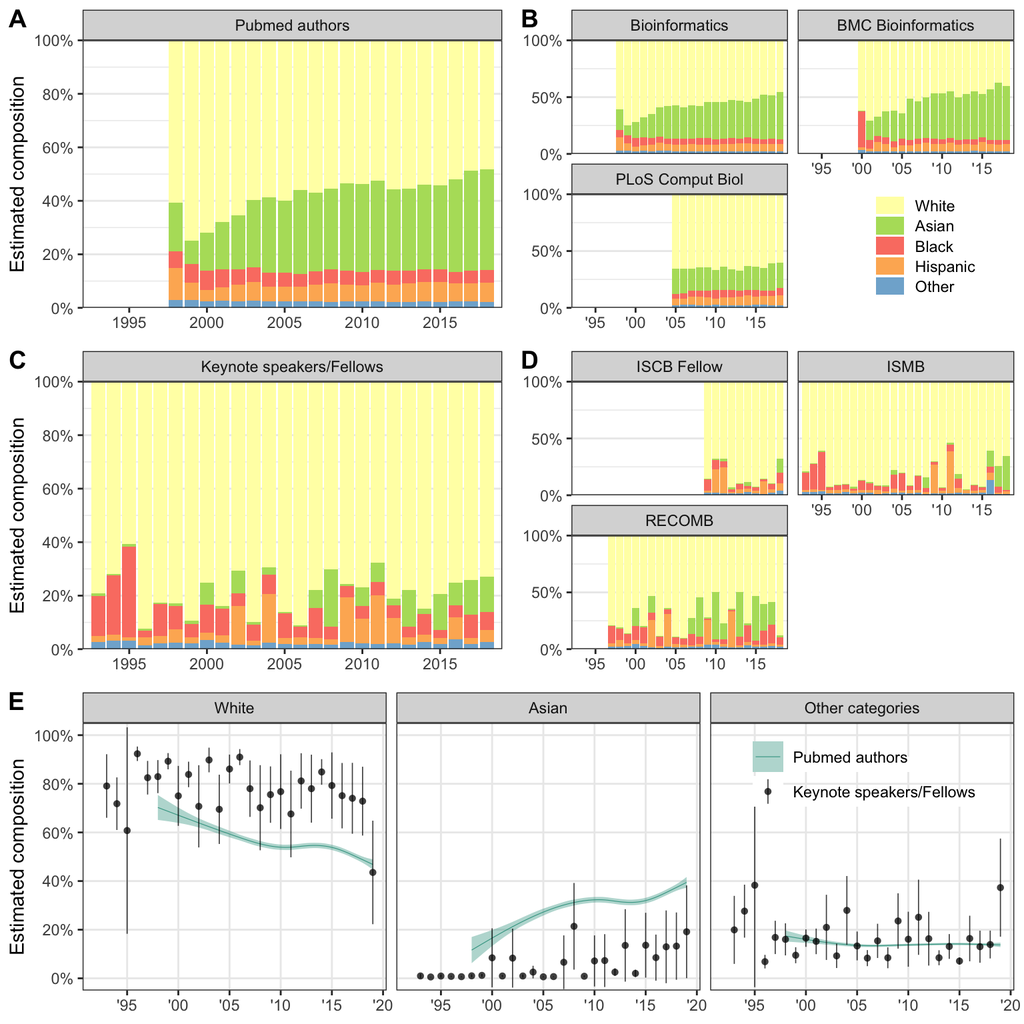

```r
# A simpler figure
fig_stats <- iscb_pubmed %>%
  filter(Race %in% c('White', 'Asian', 'Other categories')) %>%
  loess_and_ci() +
  theme(legend.position = c(0.84, 0.78)) +
  facet_wrap(vars(fct_rev(Race)))

fig_2a <- iscb_pubmed %>%
  filter(Race != 'Other categories',
         type == 'Pubmed authors') %>%
  group_by(year, type, Race) %>%
  summarise(mean_prob = mean(probabilities, na.rm = T)) %>%
  ungroup() %>%
  race_breakdown(category = 'main', type)

fig_2c <- iscb_pubmed %>%
  filter(Race != 'Other categories',
         type != 'Pubmed authors') %>%
  group_by(year, type, Race) %>%
  summarise(mean_prob = mean(probabilities, na.rm = T)) %>%
  ungroup() %>%
  race_breakdown(category = 'main', type)

fig_2b <- bind_rows(pubmed_race) %>%
  race_breakdown(category = 'sub', journal) +
  theme(legend.position = c(0.8, 0.25),
        legend.key.height = unit(4, 'mm'),
        legend.background = element_rect(fill = "transparent", colour = "transparent"))

fig_2d <- bind_rows(iscb_race) %>%
  race_breakdown(category = 'sub', journal)

fig_2_a_d <- cowplot::plot_grid(fig_2a, fig_2b, fig_2c, fig_2d, labels = 'AUTO')
fig_2 <- cowplot::plot_grid(fig_2_a_d, fig_stats, labels = c('', 'E'), ncol = 1, rel_heights = c(2,1))
fig_2
```

```r
ggsave('figs/racial_makeup.png', fig_2, width = 7, height = 7)
```

### What about p-values?

```r
w_df <- iscb_pubmed %>% filter(Race == 'White', !is.na(probabilities))
w_pub <- w_df %>% filter(type == 'Pubmed authors') %>% pull(probabilities)
w_iscb <- w_df %>% filter(type != 'Pubmed authors') %>% pull(probabilities)

t.test(w_iscb, w_pub, alternative = 'greater') %>%
  broom::tidy() %>%
  select(-contains('estimate')) %>%
  print()
```

```
## # A tibble: 1 x 7
##   statistic  p.value parameter conf.low conf.high method        alternative
##       <dbl>    <dbl>     <dbl>    <dbl>     <dbl> <chr>         <chr>
## 1      15.0 6.41e-40      348.    0.209       Inf Welch Two Sa… greater
```

The Welch two-sample one-sided t-test shows that the mean probability of ISCB speakers predicted to be white is higher than that of authors.

```r
w_df <- iscb_pubmed %>% filter(Race == 'Asian', !is.na(probabilities))
w_pub <- w_df %>% filter(type == 'Pubmed authors') %>% pull(probabilities)
w_iscb <- w_df %>% filter(type != 'Pubmed authors') %>% pull(probabilities)

t.test(w_iscb, w_pub, alternative = 'less') %>%
  broom::tidy() %>%
  select(-contains('estimate')) %>%
  print()
```

```
## # A tibble: 1 x 7
##   statistic  p.value parameter conf.low conf.high method        alternative
##       <dbl>    <dbl>     <dbl>    <dbl>     <dbl> <chr>         <chr>
## 1     -21.8 2.36e-68      368.     -Inf    -0.241 Welch Two Sa… less
```

The Welch two-sample one-sided t-test shows that the mean probability of ISCB speakers predicted to be Asian is lower than that of authors.

```r
w_df <- iscb_pubmed %>% filter(Race == 'Other categories', !is.na(probabilities))
w_pub <- w_df %>% filter(type == 'Pubmed authors') %>% pull(probabilities)
w_iscb <- w_df %>% filter(type != 'Pubmed authors') %>% pull(probabilities)

t.test(w_iscb, w_pub) %>%
  broom::tidy() %>%
  select(-contains('estimate')) %>%
  print()
```

```
## # A tibble: 1 x 7
##   statistic p.value parameter conf.low conf.high method         alternative
##       <dbl>   <dbl>     <dbl>    <dbl>     <dbl> <chr>          <chr>
## 1      2.18  0.0296      336.  0.00251    0.0479 Welch Two Sam… two.sided
```

A Welch two-sample t-test also shows a higher mean probability of ISCB speakers predicted to be in Other categories compared to authors.

### Supplementary Figure S2

For each race/ethnicity category, the mean predicted probability of Pubmed articles is shown as teal LOESS curve, and the mean probability and 95% confidence interval of the ISCB honoree predictions are shown as dark circles and vertical lines.

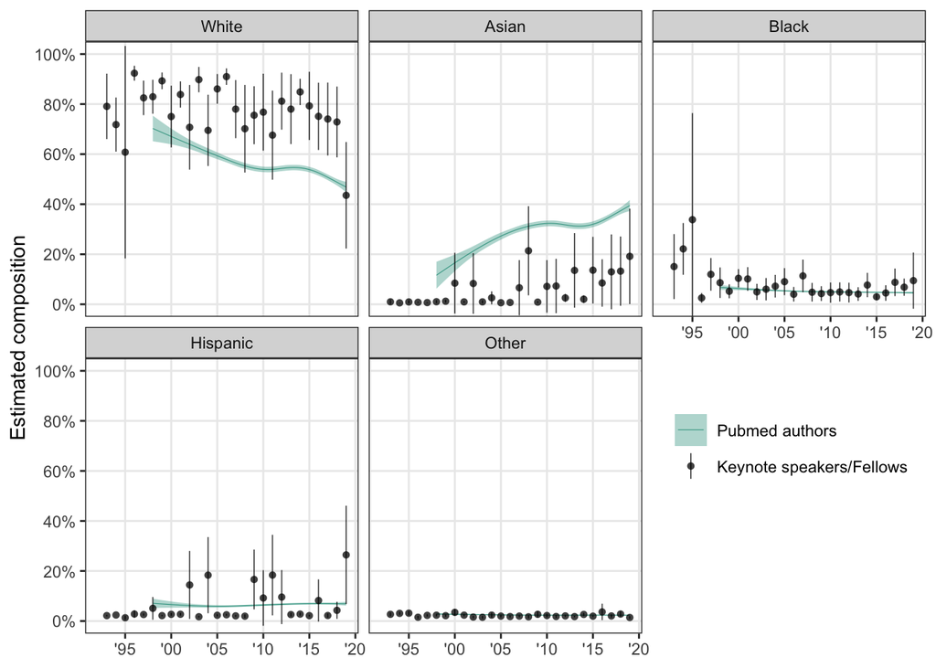

```r
fig_s2 <- iscb_pubmed %>%
  filter(Race != 'Other categories') %>%
  loess_and_ci() +
  theme(legend.position = c(0.84, 0.3)) +
  facet_wrap(vars(fct_relevel(Race, race_levels)))
fig_s2
```

```r
ggsave('figs/fig_s2.png', fig_s2, width = 6, height = 4)
```

All Asian speakers at PSB 2000?

```r
iscb_race_df %>% filter(year == '2000-01-01', conference == 'PSB')
```

```
##  [1] year             full_name.x      fore_name        last_name
##  [5] conference       source           affiliations     afflcountries
##  [9] fore_name_simple surname          full_name.y      pred.whi
## [13] pred.bla         pred.his         pred.asi         pred.oth
## <0 rows> (or 0-length row.names)
```

PSB only had one keynote speaker in 2000, Wah Chiu.

What’s in Bioinformatics 1999?

```r
pubmed_race_pmids %>%
  filter(year == '1999-01-01' & !is.na(pred.whi)) %>%
  select(contains('pred')) %>%
  colMeans()
```

```
##   pred.whi   pred.bla   pred.his   pred.asi   pred.oth
## 0.74829564 0.06930611 0.06557128 0.08713391 0.02969306
```

```r
pubmed_race_pmids %>%
  filter(year == '1999-01-01' & !is.na(pred.whi)) %>%
  filter(pred.asi > 0.1) %>%
  select(fore_name, surname, pred.asi)
```

```
##    fore_name surname  pred.asi
## 1          O    poch 0.1342000
## 2          M   afzal 0.8004200
## 3        H J     kim 0.9446055
## 4        K M    chao 0.8670867
## 5        A K  bansal 0.9475000
## 6          K   nakai 0.3584642
## 7        A S   reddy 0.6612000
## 8          A    sali 0.1155000
## 9        A E   torda 0.2910291
## 10         L   zhang 0.9806000
```

```r
pubmed_race_pmids %>%
  filter(year == '1999-01-01' & !is.na(pred.whi)) %>%
  filter(pred.his > 0.1) %>%
  select(fore_name, surname, pred.his)
```

```
##   fore_name        surname  pred.his
## 1         P rodriguez-tomé 0.9377938
## 2         R          rozas 0.3190000
## 3       J J           rosa 0.6495350
## 4       M P        lefranc 0.2014000
## 5         A       valencia 0.8923000
## 6       A E          torda 0.1005101
```